# **Assignment 4**

#### **Topic:** Physical Activity and Transit (PAT) Survey Wave 1/ Wave 2

**Set up needed libraries**

```r
library(tidyverse)
library(caret)
library(cluster)
library(factoextra)

set.seed(123)
```

**Import dataset**

```
## # A tibble: 3,811 × 17
##     ...1 chronic1 chronic3 chronic4   bmi tobacco1 alcohol1 gpaq8totmin
##    <dbl>    <dbl>    <dbl>    <dbl> <dbl>    <dbl>    <dbl>       <dbl>
##  1     1        2        2        2  26.8        3        3           0
##  2     2        2        2        2  28.2        3        3         120
##  3     3        1        1        2  39.2        1        2          60
##  4     4        2        2        1  42.5        3        3         180
##  5     5        2        2        2  22.3        3       NA           0
##  6     6        1        1        2  28.5        3        2           0
##  7     7        1        1        2  29.7        3        2           0
##  8     8        1        1        2  22.6        3        3           0
##  9     9        1        1        2  30.6        3        2          15
## 10    10        2        2        2  30.8        2        2           0
## # ℹ 3,801 more rows
## # ℹ 9 more variables: gpaq11days <dbl>, habits5 <dbl>, habits7 <dbl>,
## #   agegroup <dbl>, dem3 <dbl>, dem4 <dbl>, dem8 <dbl>, povertygroup <dbl>,
## #   healthydays <dbl>
```

**Description:** Based on the raw dataset, there are 17 columns and 3,811 rows. All variables were imported as double numeric (dbl) values. However, according to the codebook, several variables represent categorical survey responses rather than continuous measurements. Therefore, variables would be recode as either categorical (factor) or continuous (numeric) to ensure they are stored and analyzed appropriately.

### **Part I: Implementing a Simple Prediction Pipeline**

The New York City Department of Health administered a questionnaire on general health and physical activity among residents. Using the dataset `class4_p1.csv`, fit and evaluate **two prediction models** using linear regression.

The aim of the models are to predict *the number of days in a month* an individual reported having good physical health (feature name: *healthydays*).

Your analytic pipeline should include the following:

**1. Perform basic data cleaning.**

```r
p1_df_clean = p1_df %>%
  # Drop the first column
  select(-`...1`) %>%

  # Convert categorical variables to factors
  mutate(
    chronic1 = as.factor(chronic1),
    chronic3 = as.factor(chronic3),
    chronic4 = as.factor(chronic4),
    tobacco1 = as.factor(tobacco1),
    alcohol1 = as.factor(alcohol1),
    habits5 = as.factor(habits5),
    habits7 = as.factor(habits7),
    agegroup = as.factor(agegroup),
    dem3 = as.factor(dem3),
    dem4 = as.factor(dem4),
    dem8 = as.factor(dem8),
    povertygroup = as.factor(povertygroup)
  ) %>%

  # Ensure continuous variables are numeric
  mutate(
    bmi = as.numeric(bmi),
    gpaq8totmin = as.numeric(gpaq8totmin),
    gpaq11days = as.numeric(gpaq11days),
    healthydays = as.numeric(healthydays)
  )

p1_df_clean %>%
  glimpse()
```

```
## Rows: 3,811
## Columns: 16
## $ chronic1     <fct> 2, 2, 1, 2, 2, 1, 1, 1, 1, 2, 2, 2, 1, 1, 1, 1, 1, 2, 1, …
## $ chronic3     <fct> 2, 2, 1, 2, 2, 1, 1, 1, 1, 2, 2, 2, NA, 2, 2, 1, 2, 2, 2,…
## $ chronic4     <fct> 2, 2, 2, 1, 2, 2, 2, 2, 2, 2, 2, 2, 1, 2, 2, 2, 2, 2, 2, …
## $ bmi          <dbl> 26.77441, 28.18891, 39.15126, 42.50945, 22.31201, 28.4780…
## $ tobacco1     <fct> 3, 3, 1, 3, 3, 3, 3, 3, 3, 2, 1, 3, 2, 3, 3, 3, 3, 3, 2, …
## $ alcohol1     <fct> 3, 3, 2, 3, NA, 2, 2, 3, 2, 2, 3, 3, 3, 3, NA, 3, 3, 2, 3…
## $ gpaq8totmin  <dbl> 0, 120, 60, 180, 0, 0, 0, 0, 15, 0, 60, 0, 0, 120, 60, 0,…
## $ gpaq11days   <dbl> 5, 5, 3, 5, 7, 7, 7, 5, 5, 7, 3, 6, 7, 5, 7, 7, 7, 5, 7, …
## $ habits5      <fct> 3, 1, 1, 2, 2, 3, 2, 3, 4, 2, 1, 2, 3, 2, 1, 2, 2, 3, 2, …
## $ habits7      <fct> NA, NA, NA, NA, NA, NA, NA, NA, NA, NA, NA, NA, NA, NA, N…
## $ agegroup     <fct> 1, 3, 3, 2, 2, 3, 3, 4, 3, 2, 2, 2, 3, 3, 3, 3, 3, 2, 2, …
## $ dem3         <fct> 2, 2, 1, 2, 2, 1, 1, 1, 2, 1, 2, 2, 2, 2, 2, 2, 2, 2, 2, …
## $ dem4         <fct> 1, 2, 1, 1, 2, 2, 1, 1, 1, 1, 2, 2, 2, 2, 2, 2, 1, 1, 1, …
## $ dem8         <fct> 2, 2, 1, 2, 2, 1, 2, 2, 1, 1, 1, 1, 2, 1, 2, 2, 2, 1, 1, …
## $ povertygroup <fct> 1, 3, 6, 2, 6, 3, 4, 6, 3, 1, 2, 1, 1, 4, 3, 1, 1, 1, 6, …
## $ healthydays  <dbl> 24, 30, NA, 23, 30, 30, 30, 10, 0, 30, 0, 30, NA, 29, 30,…
```

**2. Partition data into training and testing (use a 70/30 split)**

```r
# Remove rows with missing (NA) outcome variable
p1_df_clean = p1_df_clean %>%
  filter(!is.na(healthydays))

# Create training and testing partitions
train_index = createDataPartition(p1_df_clean$healthydays,
                                  p = 0.70, list = FALSE)

train_df = p1_df_clean[train_index, ]
test_df  = p1_df_clean[-train_index, ]

# Check number of observation in each set
cat("Training set:", nrow(train_df), "observations\n")
```

```
## Training set: 2607 observations
```

```r
cat("Test set:", nrow(test_df), "observations\n")
```

```
## Test set: 1116 observations
```

**Note:** After using a 70/30 split, there are 2,607 and 1,116 observation in training set and test set, respectively.

**3. Fit two prediction models using different subsets of the features in the training data.**

Features can overlap in the two models, but the feature sets should not be exactly the same across models. Clearly state which features were used in the two models.

```r
# Set up cross-validation
control_settings = trainControl(method = "cv", number = 10)
```

**Model 1: Demographic characteristics (age, sex, poverty) and chronic disease predictors (hypertension, diabetes, asthma) ot predict healthy days**

Features: `agegroup`,`dem3`,`povertygroup`,`chronic1`,`chronic3`,`chronic4`,`bmi`

```r
set.seed(123)

model1 = train(
  healthydays ~ agegroup + dem3 + povertygroup + chronic1 + chronic3 + chronic4 + bmi,
  data = train_df,
  method = "lm",
  preProc = c("center", "scale"),
  trControl = control_settings,
  metric = "RMSE",
  na.action = na.omit
)

# Model 1 results
model1
```

```
## Linear Regression
##
## 2607 samples
##    7 predictor
##
## Pre-processing: centered (13), scaled (13)
## Resampling: Cross-Validated (10 fold)
## Summary of sample sizes: 2152, 2152, 2153, 2153, 2153, 2153, ...
## Resampling results:
##
##   RMSE      Rsquared   MAE
##   7.294672  0.1172464  4.618928
##
## Tuning parameter 'intercept' was held constant at a value of TRUE
```

```r
model1$results
```

```
##   intercept     RMSE  Rsquared      MAE    RMSESD RsquaredSD     MAESD
## 1      TRUE 7.294672 0.1172464 4.618928 0.5398485 0.04109157 0.3155241
```

```r
summary(model1$finalModel)
```

```
##
## Call:
## lm(formula = .outcome ~ ., data = dat)
##
## Residuals:
##      Min       1Q   Median       3Q      Max
## -30.1678  -0.1562   1.7198   3.6823  13.3971
##
## Coefficients:
##               Estimate Std. Error t value Pr(>|t|)
## (Intercept)    26.3909     0.1490 177.115  < 2e-16 ***
## agegroup2      -0.6114     0.2890  -2.115   0.0345 *
## agegroup3      -1.2406     0.3082  -4.025 5.87e-05 ***
## agegroup4      -1.5057     0.2821  -5.338 1.03e-07 ***
## dem32          -0.2159     0.1510  -1.430   0.1527
## povertygroup2   0.3977     0.1864   2.133   0.0330 *
## povertygroup3   1.0678     0.1909   5.593 2.49e-08 ***
## povertygroup4   0.9839     0.1895   5.193 2.25e-07 ***
## povertygroup5   1.3351     0.1973   6.767 1.65e-11 ***
## povertygroup6   0.1873     0.1764   1.062   0.2884
## chronic12       0.7757     0.1764   4.398 1.14e-05 ***
## chronic32       0.7694     0.1607   4.787 1.79e-06 ***
## chronic42       1.1464     0.1509   7.596 4.38e-14 ***
## bmi            -0.1551     0.1561  -0.993   0.3207
## ---
## Signif. codes:  0 '***' 0.001 '**' 0.01 '*' 0.05 '.' 0.1 ' ' 1
##
## Residual standard error: 7.288 on 2378 degrees of freedom
## Multiple R-squared:  0.1244, Adjusted R-squared:  0.1196
## F-statistic: 25.98 on 13 and 2378 DF,  p-value: < 2.2e-16
```

**Model 2: Adding more predictors into Model 1 by adding physical activity variables (days walked for transportation, minutes of home physical activity, self-rated activity level) and lifestyle factors (smoking, alcohol assumption)**

Features: Model 1 and `gpaq8totmin`, `gpaq11days`, `habits5`, `tobacco1`, `alcohol1`

```r
set.seed(123)

model2 = train(
  healthydays ~ agegroup + dem3 + povertygroup + chronic1 + chronic3 + chronic4 +
                bmi + gpaq8totmin + gpaq11days + habits5 + tobacco1 + alcohol1,
  data = train_df,
  method = "lm",
  preProc = c("center", "scale"),
  trControl = control_settings,
  metric = "RMSE",
  na.action = na.omit
)

# Model 2 results
model2
```

```
## Linear Regression
##
## 2607 samples
##   12 predictor
##
## Pre-processing: centered (22), scaled (22)
## Resampling: Cross-Validated (10 fold)
## Summary of sample sizes: 2131, 2132, 2132, 2133, 2132, 2132, ...
## Resampling results:
##
##   RMSE      Rsquared   MAE
##   7.187293  0.1498862  4.545748
##
## Tuning parameter 'intercept' was held constant at a value of TRUE
```

```r
model2$results
```

```
##   intercept     RMSE  Rsquared      MAE   RMSESD RsquaredSD     MAESD
## 1      TRUE 7.187293 0.1498862 4.545748 0.481089 0.03050275 0.3100237
```

```r
summary(model2$finalModel)
```

```
##
## Call:
## lm(formula = .outcome ~ ., data = dat)
##
## Residuals:
##      Min       1Q   Median       3Q      Max
## -30.0270  -0.4694   1.5638   3.6233  13.6190
##
## Coefficients:
##               Estimate Std. Error t value Pr(>|t|)
## (Intercept)   26.37949    0.14700 179.449  < 2e-16 ***
## agegroup2     -0.56624    0.28638  -1.977 0.048131 *
## agegroup3     -1.15500    0.30627  -3.771 0.000166 ***
## agegroup4     -1.40475    0.28183  -4.984 6.67e-07 ***
## dem32         -0.13543    0.15183  -0.892 0.372470
## povertygroup2  0.32866    0.18471   1.779 0.075305 .
## povertygroup3  1.01030    0.18938   5.335 1.05e-07 ***
## povertygroup4  0.91277    0.18828   4.848 1.33e-06 ***
## povertygroup5  1.13720    0.19815   5.739 1.07e-08 ***
## povertygroup6  0.08951    0.17419   0.514 0.607395
## chronic12      0.64739    0.17500   3.699 0.000221 ***
## chronic32      0.63279    0.15931   3.972 7.34e-05 ***
## chronic42      1.02620    0.15048   6.820 1.16e-11 ***
## bmi            0.08274    0.15659   0.528 0.597255
## gpaq8totmin   -0.10537    0.15030  -0.701 0.483323
## gpaq11days     0.40186    0.15317   2.624 0.008759 **
## habits52      -0.35503    0.17109  -2.075 0.038087 *
## habits53      -0.93324    0.17289  -5.398 7.42e-08 ***
## habits54      -1.30102    0.15946  -8.159 5.44e-16 ***
## tobacco12     -0.08388    0.17707  -0.474 0.635727
## tobacco13      0.29044    0.17857   1.626 0.103987
## alcohol12     -0.23995    0.45945  -0.522 0.601552
## alcohol13     -0.47177    0.46272  -1.020 0.308038
## ---
## Signif. codes:  0 '***' 0.001 '**' 0.01 '*' 0.05 '.' 0.1 ' ' 1
##
## Residual standard error: 7.155 on 2346 degrees of freedom
## Multiple R-squared:  0.1632, Adjusted R-squared:  0.1553
## F-statistic: 20.79 on 22 and 2346 DF,  p-value: < 2.2e-16
```

**4. Apply both models within the test data and determine which model is the preferred prediction model using the appropriate evaluation metric(s).**

```r
# Generate predictions on test set
pred1 = predict(model1, newdata = test_df)
pred2 = predict(model2, newdata = test_df)

# Identify complete cases (rows without missing predictions)
complete_cases1 = complete.cases(test_df[, c("agegroup", "dem3", "povertygroup", "chronic1", "chronic3", "chronic4", "bmi")])
complete_cases2 = complete.cases(test_df[, c("agegroup", "dem3", "povertygroup", "chronic1", "chronic3", "chronic4", "bmi", "gpaq8totmin", "gpaq11days", "habits5", "tobacco1", "alcohol1")])

# Create results data frames with matching rows
test_outcome_model1 = data.frame(
  observed = test_df$healthydays[complete_cases1],
  predicted = pred1
)

test_outcome_model2 = data.frame(
  observed = test_df$healthydays[complete_cases2],
  predicted = pred2
)

# Calculate evaluation metrics
eval_model1 = postResample(pred = test_outcome_model1$predicted,
                            obs = test_outcome_model1$observed)
eval_model2 = postResample(pred = test_outcome_model2$predicted,
                            obs = test_outcome_model2$observed)

# Create comparison table with formatted values
model_comparison = data.frame(
  Model = c("Model 1: Demographics + underlying chronic disease",
            "Model 2: Model 1 + physical activity + lifestyle"),
  RMSE = round(c(eval_model1["RMSE"], eval_model2["RMSE"]), 3),
  Rsquared = round(c(eval_model1["Rsquared"], eval_model2["Rsquared"]), 3),
  MAE = round(c(eval_model1["MAE"], eval_model2["MAE"]), 3),
  N_Predictors = c(7, 12)
)

# Display table using kable for clean formatting
knitr::kable(model_comparison,
             col.names = c("Model", "RMSE", "R²", "MAE", "N Predictors"),
             align = c("l", "c", "c", "c", "c"),
             caption = "Table 1. Model Performance Comparison on Test Set")
```

Table 1. Model Performance Comparison on Test Set

| Model | RMSE | R² | MAE | N Predictors |
| --- | --- | --- | --- | --- |
| Model 1: Demographics + underlying chronic disease | 7.631 | 0.075 | 4.837 | 7 |
| Model 2: Model 1 + physical activity + lifestyle | 7.581 | 0.087 | 4.800 | 12 |

**Model Selection:** Based on the evaluation metrics in Table 1, **Model 2** has lower prediction error (RMSE = 7.581 < 7.631) and higher proportion of variance (R² = 8.7% > 7.5%) compared to Model 1. These values reflect that adding physical activity and lifestyle factors into the model help to improve prediction accuracy beyond demographics and chronic conditions alone (Model 1). Therefore, **Model 2** is the preferred prediction model.

**5. Describe one setting (in 1-2 sentences) where the implementation of your final model would be useful.**

**Answer:** Model 2 could be applied within New York City chronic disease management programs to identify residents who are more likely to experience fewer healthy days each month based on demographic characteristics, health status, and physical activity patterns. These predictions could help health officials prioritize high-risk individuals for targeted interventions, such as community exercise initiatives or personalized health coaching.

### **Part II: Conducting an Unsupervised Analysis**

Using the dataset from the Group assignment Part 3 (USArrests), identify clusters using hierarchical analysis.

**Import data**

```r
data("USArrests")
USArrests
```

```
##                Murder Assault UrbanPop Rape
## Alabama          13.2     236       58 21.2
## Alaska           10.0     263       48 44.5
## Arizona           8.1     294       80 31.0
## Arkansas          8.8     190       50 19.5
## California        9.0     276       91 40.6
## Colorado          7.9     204       78 38.7
## Connecticut       3.3     110       77 11.1
## Delaware          5.9     238       72 15.8
## Florida          15.4     335       80 31.9
## Georgia          17.4     211       60 25.8
## Hawaii            5.3      46       83 20.2
## Idaho             2.6     120       54 14.2
## Illinois         10.4     249       83 24.0
## Indiana           7.2     113       65 21.0
## Iowa              2.2      56       57 11.3
## Kansas            6.0     115       66 18.0
## Kentucky          9.7     109       52 16.3
## Louisiana        15.4     249       66 22.2
## Maine             2.1      83       51  7.8
## Maryland         11.3     300       67 27.8
## Massachusetts     4.4     149       85 16.3
## Michigan         12.1     255       74 35.1
## Minnesota         2.7      72       66 14.9
## Mississippi      16.1     259       44 17.1
## Missouri          9.0     178       70 28.2
## Montana           6.0     109       53 16.4
## Nebraska          4.3     102       62 16.5
## Nevada           12.2     252       81 46.0
## New Hampshire     2.1      57       56  9.5
## New Jersey        7.4     159       89 18.8
## New Mexico       11.4     285       70 32.1
## New York         11.1     254       86 26.1
## North Carolina   13.0     337       45 16.1
## North Dakota      0.8      45       44  7.3
## Ohio              7.3     120       75 21.4
## Oklahoma          6.6     151       68 20.0
## Oregon            4.9     159       67 29.3
## Pennsylvania      6.3     106       72 14.9
## Rhode Island      3.4     174       87  8.3
## South Carolina   14.4     279       48 22.5
## South Dakota      3.8      86       45 12.8
## Tennessee        13.2     188       59 26.9
## Texas            12.7     201       80 25.5
## Utah              3.2     120       80 22.9
## Vermont           2.2      48       32 11.2
## Virginia          8.5     156       63 20.7
## Washington        4.0     145       73 26.2
## West Virginia     5.7      81       39  9.3
## Wisconsin         2.6      53       66 10.8
## Wyoming           6.8     161       60 15.6
```

**6. Conduct a hierarchical clustering analysis. Use a Euclidian distance measure to construct your dissimilarity matrix. Use complete linkage.**

```r
# Check if scaling is needed
colMeans(USArrests, na.rm = TRUE)
```

```
##   Murder  Assault UrbanPop     Rape
##    7.788  170.760   65.540   21.232
```

```r
apply(USArrests, 2, sd, na.rm = TRUE)
```

```
##    Murder   Assault  UrbanPop      Rape
##  4.355510 83.337661 14.474763  9.366385
```

**Note:** Variables have substantially different scales (e.g., Assault mean = 170.76, SD = 83.34 vs Murder mean = 7.79, SD = 4.36), which would cause Assault to dominate distance calculations. Therefore, standardization (mean=0, SD=1) is applied to ensure equal contribution from all variables.

```r
# Scale
arrests_scaled = scale(USArrests)
```

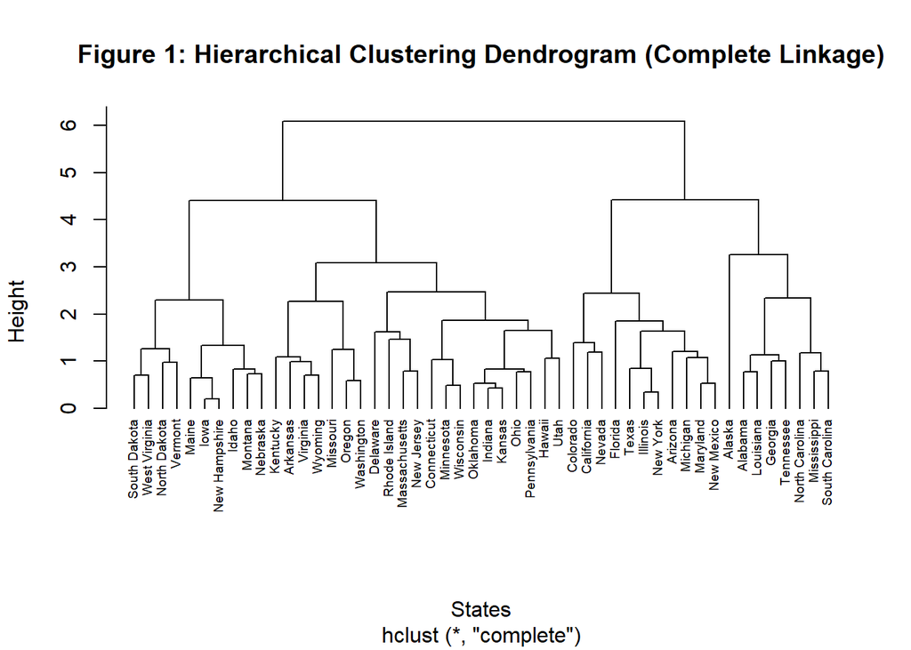

```r
set.seed(123)

# Create dissimilarity matrix using Euclidean distance
diss_matrix = dist(arrests_scaled, method = "euclidean")

# Hierarchical clustering using complete linkage
clusters_h = hclust(diss_matrix, method = "complete")

# Plot dendrogram
plot(clusters_h, cex = 0.6, hang = -1,
     main = "Figure 1: Hierarchical Clustering Dendrogram (Complete Linkage)",
     xlab = "States", ylab = "Height")
```

**Description:** In **Figure 1**, the dendrogram illustrates the hierarchical structure of all 50 US states based on their violent crime rates and urbanization. The height of each branch represents dissimilarity (Euclidean distance) between clusters. The major split occurring near the top of the tree (height ≈ 6) divides the 50 states into two primary groups: high-crime and low-crime states.

**7. Determine the optimal number of clusters using a clear, data-driven strategy.**

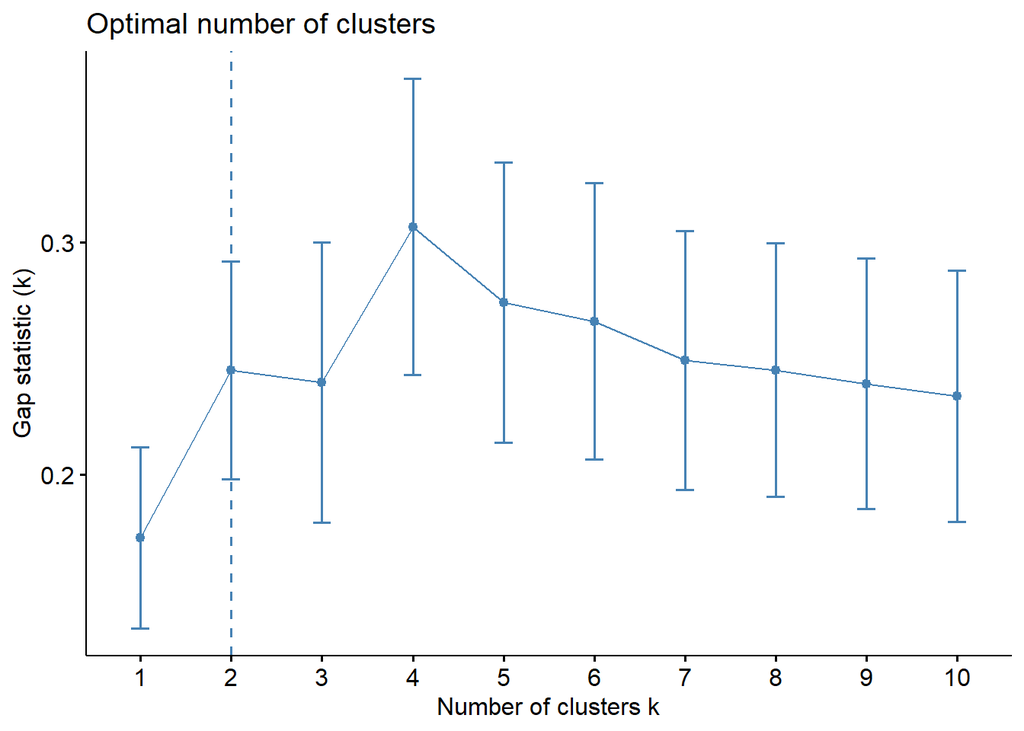

```r
set.seed(123)

# Create function for hclust with cutree
hclust_cut = function(x, k) {
  list(cluster = cutree(hclust(dist(x, method = "euclidean"),
                                method = "complete"), k = k))
}

# Perform gap statistic analysis
gap_stat = clusGap(arrests_scaled, FUN = hclust_cut, K.max = 10, B = 50)

# Visualize gap statistic
fviz_gap_stat(gap_stat)
```

```r
# Print gap statistic results
print(gap_stat, method = "firstmax")
```

```
## Clustering Gap statistic ["clusGap"] from call:
## clusGap(x = arrests_scaled, FUNcluster = hclust_cut, K.max = 10, B = 50)
## B=50 simulated reference sets, k = 1..10; spaceH0="scaledPCA"
##  --> Number of clusters (method 'firstmax'): 2
##           logW   E.logW       gap     SE.sim
##  [1,] 3.458369 3.631167 0.1727975 0.03896440
##  [2,] 3.142869 3.387856 0.2449876 0.04684770
##  [3,] 3.024738 3.264527 0.2397887 0.06024212
##  [4,] 2.853452 3.160220 0.3067677 0.06370782
##  [5,] 2.794753 3.068935 0.2741817 0.06035043
##  [6,] 2.716058 2.982189 0.2661316 0.05944515
##  [7,] 2.651864 2.901169 0.2493054 0.05582370
##  [8,] 2.582052 2.827215 0.2451636 0.05461940
##  [9,] 2.518974 2.758152 0.2391780 0.05394907
## [10,] 2.457444 2.691261 0.2338168 0.05416721
```

**Note:** From the Gap statistic result, **the optimal number of cluster is 2**.

```r
# Use optimal number of clusters from gap statistic (adjust k based on your results)
optimal_k = 2

# Assign cluster membership
clusters_final = cutree(clusters_h, k = optimal_k)

# Display cluster assignments
table(clusters_final)
```

```
## clusters_final
##  1  2
## 19 31
```

```r
# Add cluster assignments to original data
arrests_with_clusters = cbind(USArrests, cluster = clusters_final)
```

**Description:** According to the gap statistic using the “firstmax” method, the optimal number of cluster is 2. We can divide the 50 states into 2 groups

- Group 1 (Cluster 1) = 19 states
- Group 2 (Cluster 2) = 31 states.

**8. Describe the composition of each cluster in terms of the original input features**

```r
# Calculate mean values of features within each cluster
cluster_summary = arrests_with_clusters %>%
  group_by(cluster) %>%
  summarise_all(mean)

# Display cluster composition table
knitr::kable(cluster_summary,
             digits = 2,
             caption = "Table 2: Mean Feature Values by Cluster",
             col.names = c("Cluster", "Murder", "Assault", "Urban Pop (%)", "Rape"))
```

Table 2: Mean Feature Values by Cluster

| Cluster | Murder | Assault | Urban Pop (%) | Rape |
| --- | --- | --- | --- | --- |
| 1 | 12.33 | 259.32 | 68.32 | 29.22 |
| 2 | 5.00 | 116.48 | 63.84 | 16.34 |

```r
# Show which states are in each cluster (optional but helpful)
for(i in 1:optimal_k) {
  cat("\nCluster", i, "states:\n")
  cat(rownames(USArrests)[clusters_final == i], sep = ", ")
  cat("\n")
}
```

```
##
## Cluster 1 states:
## Alabama, Alaska, Arizona, California, Colorado, Florida, Georgia, Illinois, Louisiana, Maryland, Michigan, Mississippi, Nevada, New Mexico, New York, North Carolina, South Carolina, Tennessee, Texas
##
## Cluster 2 states:
## Arkansas, Connecticut, Delaware, Hawaii, Idaho, Indiana, Iowa, Kansas, Kentucky, Maine, Massachusetts, Minnesota, Missouri, Montana, Nebraska, New Hampshire, New Jersey, North Dakota, Ohio, Oklahoma, Oregon, Pennsylvania, Rhode Island, South Dakota, Utah, Vermont, Virginia, Washington, West Virgi…
```

**Cluster interpretation:**

**9. Pretend that the data are from 2022 and not 1973. Describe one research question that can be addressed using the newly identified clusters. Briefly comment on any scientific or ethical considerations one should review before using these clusters for your specific question. NOTE: The clusters can be used as an exposure, an outcome or a covariate. (2-4 sentences)**

**Answer:** If the data was from 2022, a research question that could be asked is *Were states in the high-crime cluster more vulnerable to pandemic-related increases in domestic violence and assault compared to low-crime cluster states during COVID-19 lockdowns*.

- *Considerations*: Ethically, it is essential to ensure that the findings do not further stigmatize vulnerable communities or become a justification for reducing public health services. Scientifically, researchers need to account for possible underreporting during lockdowns and distinguish true increases in crime from changes in reporting behavior.

**10. Optional Repeat analysis with a different linkage method (e.g. single or average). Do the clusters change?**

- **Single linkage method**

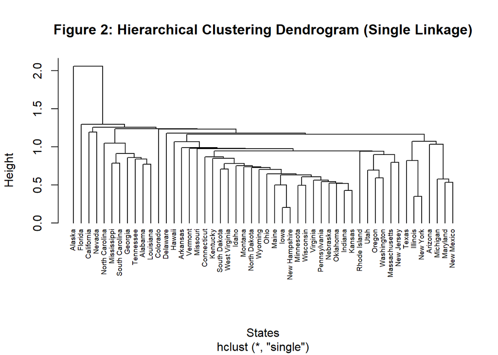

```r
set.seed(123)

# Hierarchical clustering using single linkage
clusters_h_single = hclust(diss_matrix, method = "single")

# Plot dendrogram
plot(clusters_h_single, cex = 0.6, hang = -1,
     main = "Figure 2: Hierarchical Clustering Dendrogram (Single Linkage)",
     xlab = "States", ylab = "Height")
```

```r
# Assign clusters using same k
clusters_single = cutree(clusters_h_single, k = optimal_k)

# Compare cluster assignments
comparison_table = table(Complete = clusters_final, Single = clusters_single)
print(comparison_table)
```

```
##         Single
## Complete  1  2
##        1 18  1
##        2 31  0
```

- **Average linkage method**

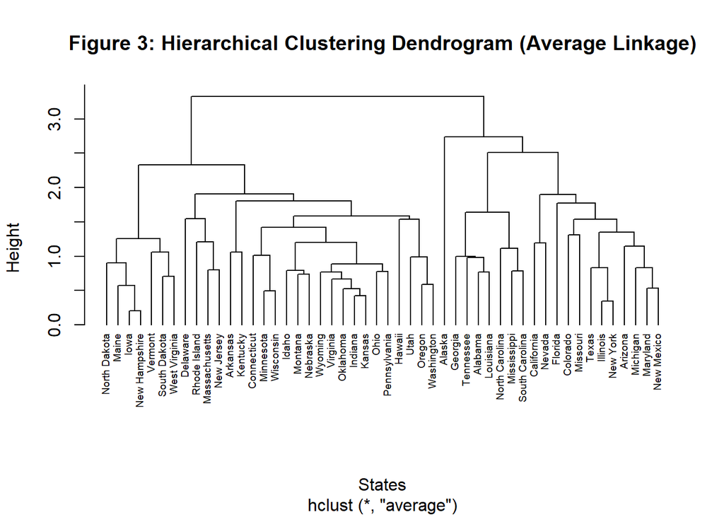

```r
set.seed(123)

# Hierarchical clustering using average linkage
clusters_h_average = hclust(diss_matrix, method = "average")

# Plot dendrogram
plot(clusters_h_average, cex = 0.6, hang = -1,
     main = "Figure 3: Hierarchical Clustering Dendrogram (Average Linkage)",
     xlab = "States", ylab = "Height")
```

```r
# Assign clusters using same k
clusters_average = cutree(clusters_h_average, k = optimal_k)

# Compare all three methods
comparison_all = data.frame(
  State = rownames(USArrests),
  Complete = clusters_final,
  Single = clusters_single,
  Average = clusters_average
)

head(comparison_all, 10)
```

```
##                   State Complete Single Average
## Alabama         Alabama        1      1       1
## Alaska           Alaska        1      2       1
## Arizona         Arizona        1      1       1
## Arkansas       Arkansas        2      1       2
## California   California        1      1       1
## Colorado       Colorado        1      1       1
## Connecticut Connecticut        2      1       2
## Delaware       Delaware        2      1       2
## Florida         Florida        1      1       1
## Georgia         Georgia        1      1       1
```

```r
# Calculate agreement between methods
cat("Agreement between Complete and Single:",
    sum(clusters_final == clusters_single) / length(clusters_final) * 100, "%\n")
```

```
## Agreement between Complete and Single: 36 %
```

```r
cat("Agreement between Complete and Average:",
    sum(clusters_final == clusters_average) / length(clusters_final) * 100, "%\n")
```

```
## Agreement between Complete and Average: 98 %
```

**Description:** Using different linkage methods can significantly affect both cluster assignments and the overall dendrogram structure. Complete and average linkage give very similar results (98% agreement), and both produce balanced clusters that clearly separate into two distinct groups at the beginning (Figure 3). In contrast, single linkage shows only 36% agreement with complete linkage because of the chaining effect, which leads to one large cluster with 49 states and another with only Alaska (Figure 2). IN addition, single linkage has very low merge heights, with a maximum around 2.0, while average linkage reaches about 3.0. These differences reflect how each method measures dissimilarity. Overall, complete linkage is the most appropriate method for this dataset. It produces compact, clearly separated clusters and avoids the chaining problem that makes single linkage difficult to interpret.

### **AI tools**

Claude.ai was used in this assignment to assist with debugging R code syntax errors and editing text for clarity and conciseness.